# lab5

```python
import numpy as np
import matplotlib
import matplotlib.pyplot as plt
import scipy as stats
import h5py
import pickle
import pandas as pd
import sklearn
```

```python
higgs_dataset_1 = open ("higgs_100000_pt_250_500.pkl", 'rb')
higgs = pickle.load(higgs_dataset_1)

qcd_dataset_2 = open ("qcd_100000_pt_250_500.pkl", 'rb')
qcd = pickle.load(qcd_dataset_2)

print(higgs)
print(qcd)
```

```
               pt       eta       phi        mass       ee2       ee3  \
0      472.074292  0.137052 -2.535145  125.150365  0.126581  0.002633
1      470.405678 -0.039157  0.069669  130.552672  0.118071  0.002379
2      438.008357 -0.181139 -3.031083  125.703063  0.167344  0.004623
3      484.860421  0.251986  2.855706  126.215853  0.119238  0.002066
4      486.141137 -1.917812 -2.221953  132.182504  0.103632  0.001438
...           ...       ...       ...         ...       ...       ...
99995  478.658254 -0.837586 -2.609921  125.707302  0.138041  0.001494
99996  465.171259  0.429341 -1.446681  129.749906  0.135890  0.002071
99997  466.920808 -0.805493 -0.754703   49.069161  0.020281  0.000121
99998  471.611853  0.801813 -3.077883  117.186361  0.102276  0.002399
99999  467.029906 -0.432315  2.483939   64.187269  0.031847  0.000260

              d2  angularity        t1        t2        t3       t21  \
0       1.298020    0.008218  0.739787  0.283689  0.174944  0.383474
```

[output cut: 65 more lines]

In the second dataset of higgs and QCD, we have following features:

pt: transverse momentum eta: pseudorapidity phi: azimuthal angle mass: mass of the particle ee2: 2-point ECF ratio ee3： 3-point ECF ratio d2: 3 to 2 point ECF ratio angularity: orientation of one feature to another at a referenced angle t1: 1-subjettiness t2: 2-subjettiness t3: 3-subjettiness t21: 21-subjettiness t32: 32-subjettiness

According to the introduction in the research report, the ratio of 2-point and 3-point generalized energy correlation functions can describe a distinct discrimination between signals as higgs and background as QCD.

[figure not shown]

```python
plt.rcParams["figure.figsize"] = (10,6)
ax1 = plt.subplot(121)
plt.hist(qcd['ee2'][:], 500, histtype = 'bar')
plt.xlabel('ECF-2 ratio')
plt.ylabel('Frequenncy')
plt.title('background of ECF-2')
ax2 = plt.subplot(122)
plt.hist(higgs['ee2'][:], 500, histtype = 'bar')
plt.xlabel('ECF-2 ratio')
plt.ylabel('Frequency')
plt.title('signal of ECF-2)')
```

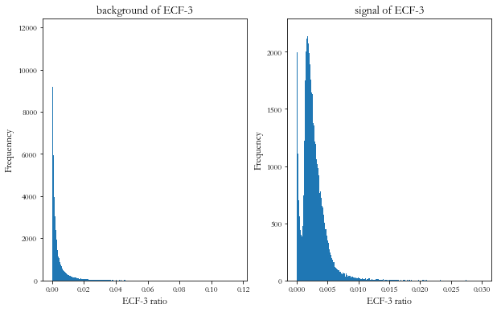

```python
plt.rcParams["figure.figsize"] = (10,6)
bins = 500
ax1 = plt.subplot(121)
plt.hist(qcd['ee3'][:], 500, histtype = 'bar')
plt.xlabel('ECF-3 ratio')
plt.ylabel('Frequenncy')
plt.title('background of ECF-3')
ax2 = plt.subplot(122)
plt.hist(higgs['ee3'][:], 500, histtype = 'bar')
plt.xlabel('ECF-3 ratio')
plt.ylabel('Frequency')
plt.title('signal of ECF-3')
```

Some general correlations between each of the features is shown in the following heatmap, with basic positive or negative correlations.

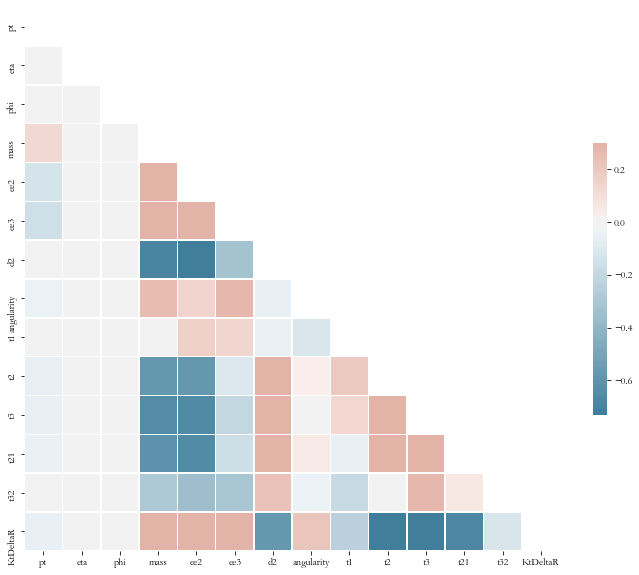

```python
import seaborn as sns
import matplotlib.pyplot as plt
plt.rcParams["figure.figsize"] = (10,10)

corr = pd.concat([higgs,qcd],axis=0).corr()
rs = np.random.RandomState(30)
d = pd.DataFrame(data=rs.normal(size=(100, 26)), columns=list(ascii_letters[26:]))
mask = np.triu(np.ones_like(corr, dtype=bool))
f, ax = plt.subplots(figsize=(12, 10))
cmap = sns.diverging_palette(230, 20, as_cmap=True)
sns.heatmap(corr, mask=mask, cmap=cmap, vmax=.3, center=0, linewidths=.5, cbar_kws={"shrink": .5})
```

[figure not shown]

```python
plt.rcParams["figure.figsize"] = (10,6)
higgs_moment = higgs['pt']
higgs_graph = plt.hist(higgs_moment, bins=200, histtype='step', label = "Higgs")
qcd_moment = qcd['pt']
qcd_graph = plt.hist(qcd_moment, bins=200, histtype='step', label = "QCD")
plt.legend()
plt.xlabel('Transverse Momentum')
plt.ylabel('number of events')
plt.show()
```

[figure not shown]

```python
plt.rcParams["figure.figsize"] = (10,6)
higgs_eta = higgs['eta']
higgs_graph_eta = plt.hist(higgs_eta,bins=500, histtype='step', label = "Higgs")
qcd_eta = qcd['eta']
qcd_graph_eta = plt.hist(qcd_eta, bins=500, histtype='step', label = "QCD")
plt.legend()
plt.xlabel('pseudorapidity')
plt.ylabel('number of events')
plt.show()
```

In the following histogram, it is obvious that the t21 of higgs and QCD has a negative relation, while t32 of higgs and QCD has a positive relation.

[figure not shown]

```python
fig, (ax1, ax2) = plt.subplots(1, 2, figsize = (10, 6))
ax1.hist(qcd['t21'], bins, alpha = 0.4, density = True); ax1.hist(higgs['t21'], 100, alpha = 0.4, density = True); ax1.set_yscale('log')
ax2.hist(qcd['t32'], bins, alpha = 0.4, density = True); ax2.hist(higgs['t32'], 100, alpha = 0.4, density = True); ax2.set_yscale('log')
ax1.set_title("relationship between t21 of higgs and QCD")
ax2.set_title("relationship between t32 of higgs and QCD")
```

Discovery of Mass can be found clearly below at about time of 125.

[figure not shown]

```python
plt.rcParams["figure.figsize"] = (10,6)
higgs_mass_graph = plt.hist(higgs['mass'],bins=500, histtype='step', label = "Higgs")
qcd_graph_eta = plt.hist(qcd['mass'], bins=500, histtype='step', label = "QCD")
plt.legend()
plt.xlabel('Mass')
plt.label('number of events')
plt.show()
```

[figure not shown]

```python
plt.rcParams["figure.figsize"] = (10,6)
plt.subplot(2,1,1)
plt.hist(higgs['KtDeltaR'][:], 300)
plt.xlabel('KtDeltaR')
plt.ylabel('number of events')
plt.title('Jet substructure moment in signal')
plt.subplot(2,1,2)
plt.subplots_adjust(hspace=0.3)
plt.hist(qcd['KtDeltaR'][:], 300)
plt.xlabel('KtDeltaR')
plt.label('number of events')
plt.title('Jet substructure moment in background')
plt.show()
```

[figure not shown]

```python
n_higgs_pt = higgs['pt'][0:10000:100]
n_qcd_pt = qcd['pt'][0:2000000:100]

plt.rcParams["figure.figsize"] = (10,6)
higgs_graph = plt.hist(n_higgs_pt, bins=200, histtype='step', label = "Higgs")
qcd_graph = plt.hist(n_qcd_pt, bins=200, histtype='step', label = "QCD")
plt.legend()
plt.xlabel('Transverse Momentum')
plt.ylabel('number of events')
plt.show()
```

[figure not shown]

```python
higgs_eta = higgs['eta'][0:10000:100]
qcd_eta = qcd['eta'][0:2000000:100]

plt.rcParams["figure.figsize"] = (10,6)
higgs_graph_eta = plt.hist(higgs_eta,bins=500, histtype='step', label = "Higgs")
qcd_graph_eta = plt.hist(qcd_eta, bins=500, histtype='step', label = "QCD")
plt.legend()
plt.xlabel('pseudorapidity')
plt.ylabel('number of events')
plt.show()
```

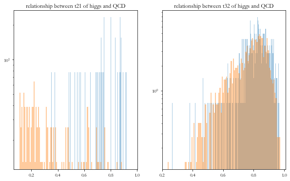

```python
fig, (ax1, ax2) = plt.subplots(1, 2, figsize = (10, 6))
ax1.hist(qcd['t21'][0:10000:100], bins, alpha = 0.4, density = True); ax1.hist(higgs['t21'][0:10000:100], 100, alpha = 0.4, density = True); ax1.set_yscale('log')
ax2.hist(qcd['t32'][0:2000000:100], bins, alpha = 0.4, density = True); ax2.hist(higgs['t32'][0:2000000:100], 100, alpha = 0.4, density = True); ax2.set_yscale('log')
ax1.set_title("relationship between t21 of higgs and QCD")
ax2.set_title("relationship between t32 of higgs and QCD")
```

A good plan to optimize the discovery sensitivity will be to compare in each feature, the area that the number of events of higgs that is much more that that of QCD.